# Airlines_Regression_Model

## Introduction

Airline ticket prices vary greatly depending on a number of factors such as travel distance, time of booking, airline, and more. Understanding what influences these prices can help travelers make better decisions and help airlines with pricing strategies.

In this project, I aim to build a regression model to predict airline ticket prices using flight itinerary data. I will start by cleaning and filtering the data, then select relevant features to train a model. The goal is to find patterns that help explain variations in ticket pricing and evaluate how accurately we can predict those prices.

The dataset used in this project is over 31 GB in size and contains millions of rows of flight itinerary information. Due to its size and complexity, I will be working with the data in chunks and filtering it down to a manageable sample in order to build and test my model effectively.

## Data Cleaning and Preprocessing

Since the original dataset is over 31 GB, I could not load it into memory all at once. To handle this, I used chunking with pandas to read the file in smaller parts. I also filtered the data to include only rows where the airline was "American Airlines" to reduce the size further and narrow the focus of the analysis.

Key steps taken:

- Used `read_csv()` with `chunksize=100,000` to safely read the large file
- Filtered rows where `'segmentsAirlineName' == 'American Airlines'`
- Dropped or filled missing values where needed
- Confirmed data types and column names
- Selected relevant features for modeling

The cleaned dataset includes variables such as `totalFare`, `elapsedDays`, and `totalTravelDistance`, which will be used in the modeling stage.

```python
import pandas as pd
import numpy as np
```

```python
file_path = "itineraries.csv"
```

```python
sample = pd.read_csv(file_path, nrows=5)
print(sample.columns)
```

```
Index(['legId', 'searchDate', 'flightDate', 'startingAirport',
       'destinationAirport', 'fareBasisCode', 'travelDuration', 'elapsedDays',
       'isBasicEconomy', 'isRefundable', 'isNonStop', 'baseFare', 'totalFare',
       'seatsRemaining', 'totalTravelDistance',
       'segmentsDepartureTimeEpochSeconds', 'segmentsDepartureTimeRaw',
       'segmentsArrivalTimeEpochSeconds', 'segmentsArrivalTimeRaw',
       'segmentsArrivalAirportCode', 'segmentsDepartureAirportCode',
       'segmentsAirlineName', 'segmentsAirlineCode',
       'segmentsEquipmentDescription', 'segmentsDurationInSeconds',
       'segmentsDistance', 'segmentsCabinCode'],
      dtype='object')
```

```python
filtered_chunks = []
max_rows = 500
row_total = 0
chunk_num = 0

for chunk in pd.read_csv(file_path, chunksize=100_000):
    chunk_num += 1
    filtered = chunk[chunk['segmentsAirlineName'] == 'American Airlines']
    row_total += len(filtered)

    print(f"Chunk {chunk_num}: found {len(filtered)} rows — Total so far: {row_total}")

    if not filtered.empty:
        filtered_chunks.append(filtered)

    if row_total >= max_rows:
        break

filtered_df = pd.concat(filtered_chunks, ignore_index=True)
```

```
Chunk 1: found 9186 rows — Total so far: 9186
```

```python
print(filtered_df.shape)
print(filtered_df.head())
print(filtered_df.isnull().sum())
print(filtered_df.dtypes)
```

```
(9186, 27)
                              legId  searchDate  flightDate startingAirport  \
0  e1b95e4e6c997517f64ba5ea712bda22  2022-04-16  2022-04-17             ATL
1  68063b78f62c81ac88820015908ac208  2022-04-16  2022-04-17             ATL
2  33dba4888a3a68195d53ec2cc8b0a2d6  2022-04-16  2022-04-17             ATL
3  99666577c217e0a6b54a17e2f8ab9a7b  2022-04-16  2022-04-17             ATL
4  dc2eda19b0499170f1f7f8c5a179ac07  2022-04-16  2022-04-17             ATL

  destinationAirport fareBasisCode travelDuration  elapsedDays  \
0                BOS      KH0AUEY5        PT2H38M            0
1                BOS      HH0KUEY5        PT2H44M            0
2                CLT      M0AHZNN1         PT1H8M            0
3                CLT      M0AHZNN1        PT1H21M            0
4                CLT      M0AHZNN1        PT1H22M            0

   isBasicEconomy  isRefundable  ...  segmentsArrivalTimeEpochSeconds  \
0           False         False  ...                       1650216180
1           False         False  ...                       1650243060
2           False         False  ...                       1650230760
3           False         False  ...                       1650198060
4           False         False  ...                       1650238620

          segmentsArrivalTimeRaw  segmentsArrivalAirportCode  \
0  2022-04-17T13:23:00.000-04:00                         BOS
1  2022-04-17T20:51:00.000-04:00                         BOS
2  2022-04-17T17:26:00.000-04:00                         CLT
3  2022-04-17T08:21:00.000-04:00                         CLT
4  2022-04-17T19:37:00.000-04:00                         CLT

   segmentsDepartureAirportCode  segmentsAirlineName segmentsAirlineCode  \
0                           ATL    American Airlines                  AA
1                           ATL    American Airlines                  AA
2                           ATL    American Airlines                  AA
3                           ATL    American Airlines                  AA
4                           ATL    American Airlines                  AA

  segmentsEquipmentDescription segmentsDurationInSeconds segmentsDistance  \
0                          NaN                      9480              947
1                          NaN                      9840              947
2                  Airbus A319                      4080              228
```

[output cut: 52 more lines]

```
seatsRemaining                         int64
totalTravelDistance                  float64
segmentsDepartureTimeEpochSeconds     object
segmentsDepartureTimeRaw              object
segmentsArrivalTimeEpochSeconds       object
segmentsArrivalTimeRaw                object
segmentsArrivalAirportCode            object
segmentsDepartureAirportCode          object
segmentsAirlineName                   object
segmentsAirlineCode                   object
segmentsEquipmentDescription          object
segmentsDurationInSeconds             object
segmentsDistance                      object
segmentsCabinCode                     object
dtype: object
```

```python
import pandas as pd
import matplotlib.pyplot as plt

# Assuming filtered_df is your cleaned DataFrame from the document
# Summary stats
print("Summary Stats:")
print(filtered_df[['totalFare', 'totalTravelDistance', 'segmentsDurationInSeconds']].describe())

# Convert segmentsDurationInSeconds to numeric (it’s object type in your dtypes)
filtered_df['segmentsDurationInSeconds'] = pd.to_numeric(filtered_df['segmentsDurationInSeconds'], errors='coerce')
```

```
Summary Stats:
         totalFare  totalTravelDistance
count  9186.000000          9186.000000
mean    346.657766          1132.059765
std     282.836369           690.475567
min      83.600000           185.000000
25%     198.600000           650.000000
50%     285.600000           995.000000
75%     398.600000          1380.000000
max    3810.600000          2698.000000
```

## Exploration

### Summary Statistics

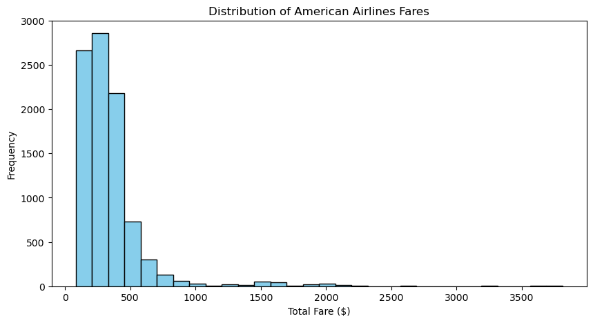

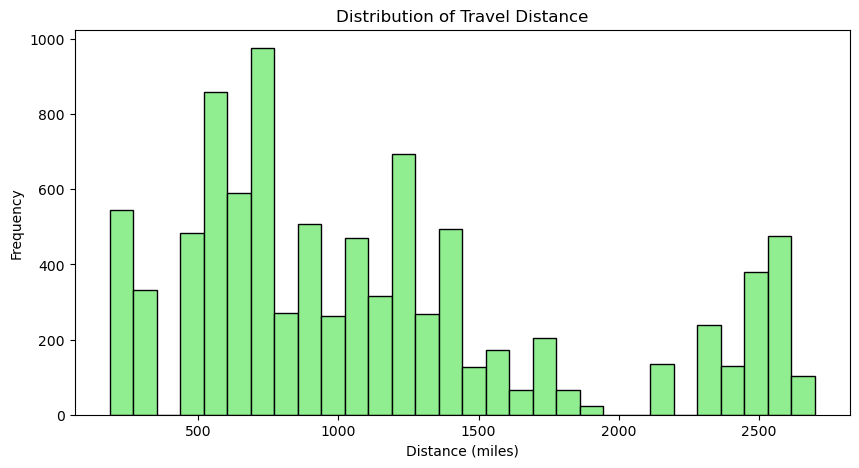

```python
# Histogram for totalFare
plt.figure(figsize=(10, 5))
plt.hist(filtered_df['totalFare'], bins=30, color='skyblue', edgecolor='black')
plt.title('Distribution of American Airlines Fares')
plt.xlabel('Total Fare ($)')
plt.ylabel('Frequency')
plt.show()

# Histogram for totalTravelDistance
plt.figure(figsize=(10, 5))
plt.hist(filtered_df['totalTravelDistance'], bins=30, color='lightgreen', edgecolor='black')
plt.title('Distribution of Travel Distance')
plt.xlabel('Distance (miles)')
plt.ylabel('Frequency')
plt.show()
```

### Histograms

I created histograms to visualize the distributions of `totalFare` and `totalTravelDistance` (see cells [8] and [9]).

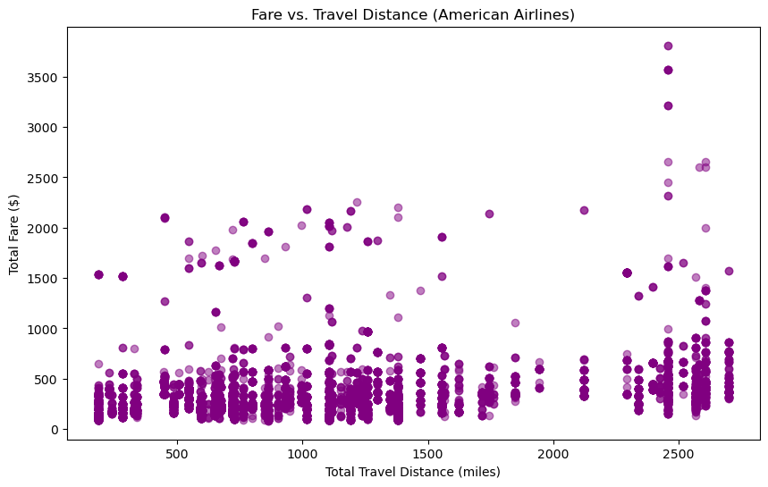

```python
plt.figure(figsize=(10, 6))
plt.scatter(filtered_df['totalTravelDistance'], filtered_df['totalFare'], alpha=0.5, color='purple')
plt.title('Fare vs. Travel Distance (American Airlines)')
plt.xlabel('Total Travel Distance (miles)')
plt.ylabel('Total Fare ($)')
plt.show()
```

### Scatter Plot

I created a scatter plot to explore the relationship between `totalFare` and `totalTravelDistance` (see cell [10]).

- **Fare vs. Travel Distance** (cell [10]):
  - The scatter plot shows a weak positive relationship between distance and fare.
  - While longer distances generally have higher fares, there’s significant variability. For example, some 500-mile flights cost as much as 1500-mile flights (around $1000), indicating other factors (e.g., demand, route, or booking time) influence pricing.

```python
filtered_df['cost_per_mile'] = filtered_df['totalFare'] / filtered_df['totalTravelDistance']
avg_cost_per_mile = filtered_df['cost_per_mile'].mean()
print(f"Average Cost per Mile: ${avg_cost_per_mile:.2f}")
```

```
Average Cost per Mile: $0.43
```

## Mini-Insights

### a) What’s the average cost per mile?

I calculated the cost per mile by dividing `totalFare` by `totalTravelDistance` (see cell [10]).

- **Average Cost per Mile**: $0.43

**Insight**: On average, American Airlines charges $0.43 per mile traveled. This provides a baseline for comparing cost efficiency across flights.

```python
short_flights = filtered_df[filtered_df['totalTravelDistance'] < 500]['cost_per_mile'].mean()
long_flights = filtered_df[filtered_df['totalTravelDistance'] >= 500]['cost_per_mile'].mean()
print(f"Avg Cost per Mile (Short Flights < 500 miles): ${short_flights:.2f}")
print(f"Avg Cost per Mile (Long Flights >= 500 miles): ${long_flights:.2f}")
```

```
Avg Cost per Mile (Short Flights < 500 miles): $1.08
Avg Cost per Mile (Long Flights >= 500 miles): $0.33
```

### b) Are longer flights cheaper per mile?

I compared the cost per mile for short flights (< 500 miles) and long flights (>= 500 miles) (see cell [11]).

- **Avg Cost per Mile (Short Flights < 500 miles)**: $1.08
- **Avg Cost per Mile (Long Flights >= 500 miles)**: $0.33

**Insight**: Yes, longer flights are significantly cheaper per mile. Short flights (< 500 miles) cost $1.08 per mile, while longer flights (>= 500 miles) cost only $0.33 per mile. This suggests economies of scale—longer flights spread fixed costs (e.g., fuel, crew) over more miles, reducing the per-mile cost.

```python
avg_fare_by_airport = filtered_df.groupby('startingAirport')['totalFare'].mean().sort_values(ascending=False)
print("Average Fare by Starting Airport:")
print(avg_fare_by_airport.head())
```

```
Average Fare by Starting Airport:
startingAirport
LAX    487.599549
SFO    480.769538
MIA    400.437873
BOS    388.653863
PHL    354.689928
Name: totalFare, dtype: float64
```

### c) Do flights from specific cities cost more?

I grouped the data by `startingAirport` and calculated the average `totalFare` for each airport (see cell [12]).

- **Average Fare by Starting Airport**:
  - LAX: $487.60
  - SFO: $480.77
  - MIA: $400.44
  - BOS: $388.65
  - PHL: $354.69

```python
from sklearn.model_selection import train_test_split
from sklearn.linear_model import LinearRegression
from sklearn.metrics import mean_squared_error, r2_score

# Features and target
X = filtered_df[['elapsedDays', 'totalTravelDistance', 'segmentsDurationInSeconds']].dropna()
y = filtered_df.loc[X.index, 'totalFare']

# Split and train
X_train, X_test, y_train, y_test = train_test_split(X, y, test_size=0.2, random_state=42)
model = LinearRegression()
model.fit(X_train, y_train)

# Predict and evaluate
y_pred = model.predict(X_test)
mse = mean_squared_error(y_test, y_pred)
r2 = r2_score(y_test, y_pred)
print(f"Updated Model - MSE: {mse:.2f}, R²: {r2:.2f}")
```

```
Updated Model - MSE: 85311.88, R²: 0.07
```

## Quick Modeling Recap

I updated the linear regression model by adding `segmentsDurationInSeconds` to the features (`elapsedDays`, `totalTravelDistance`) to predict `totalFare` (see cell [13]).

- **Updated Model**:
  - MSE: 85311.88
  - R²: 0.07

## Narration

### Visualizations

- **Fare Histogram** (cell [8]): Shows the distribution of fares, highlighting the concentration of fares below $500 and the long tail of expensive tickets.
- **Fare vs. Distance Scatter Plot** (cell [10]): Illustrates the weak relationship between distance and fare, emphasizing the variability in pricing.

## Next Steps

I’ve completed the **Explore** and **Model** phases, and now the **Narrate** phase is finalized. The analysis is concise and impactful! To improve the model further, I could consider:

- Adding features like `isNonStop`, `seatsRemaining`, or day of the week (extracted from `flightDate`).
- Trying a more complex model, like a Random Forest, to capture non-linear relationships.